Review article

The effect of bioactive glasses on spinal fusion: A cross-disciplinary

systematic review and meta-analysis of the preclinical and clinical data

Ethan Cottrill, Zach Pennington, Nithin Lankipalle, Jeff Ehresman, Cara Valencia, Andrew Schilling,

James Feghali, Alexander Perdomo-Pantoja, Nicholas Theodore, Daniel M. Sciubba, Timothy Witham <sup>⇑</sup>

Department of Neurosurgery, The Johns Hopkins University School of Medicine, Baltimore, MD, USA

a r t i c l e

i n f o

Article history:

Received 4 February 2020

Accepted 5 April 2020

Available online xxxx

Keywords:

Spinal fusion

Pseudarthrosis

Nonunion

Bioactive glass

Bioglass

a b s t r a c t

Pseudarthrosis following spinal fusion is correlated with poorer patient outcomes and consequently is an

area of continued interest within spinal research. Recently, bioactive glasses have been proposed as a

means of augmenting fusion rates. Here, we present the ﬁrst systematic review and meta-analysis of

the existing preclinical and clinical literature on the effect of bioactive glasses on spinal fusion. Using

the MEDLINE, Embase, and Web of Science databases, we queried all publications in the English-

language literature examining the effect of bioactive glasses on spinal fusion. The primary endpoint

was fusion rate at last follow-up and the secondary endpoint for clinical studies was the rate of deep

wound infection. Random-effects meta-analyses were performed independently for the preclinical and

clinical data. Twelve preclinical studies (267 animals) and 12 clinical studies (396 patients) evaluating

a total of twelve unique bioactive glass formulations were included. Across clinical studies, fusion was

seen in 84% treated with bioactive glass. On sub-analysis, fusion rates were similar for standalone auto-

graft (91.6%) and bioactive glass-local autograft mixtures (89.6%). Standalone bioactive glass substrates

produced inferior fusion rates relative to autograft alone (33.6% vs. 98.8%; OR 0.01, p < 0.02). Rates of deep

wound infection did not differ between the bioactive glass and autograft groups (3.1%). The preclinical

data similarly showed comparable rates of fusion between autograft and bioactive glass-treated animals.

The available data suggest that bioactive glass-autograft mixtures confer similar rates of spinal fusion rel-

ative to standalone autograft without altering the risk of deep wound infection.

� 2020 Elsevier Ltd. All rights reserved.

1. Introduction

Annually, some 400,000 Americans undergo spinal fusion pro-

cedures for degenerative conditions characterized by neck pain,

back pain, radiculopathy, and/or myelopathy [1]. These procedures

account for the highest aggregate hospital cost of any inpatient

procedure, estimated at $13 billion annually [2]. Previous studies

have suggested that post-operative symptomatic improvement

correlates with radiological fusion, deﬁned by continuous bony

union across the fusion site [3–5]. For this reason, great emphasis

has been placed on identifying interventions and technologies to

reduce rates of pseudarthrosis, or non-union [6–8]. Despite this,

[9–13]. One ongoing ﬁeld of investigation targeted at improving

these outcomes revolves around the creation of novel bone graft

substitute materials [14,15]. Of the products falling within this cat-

egory, one set showing promise in preliminary studies is bioactive

glasses [16,17].

Bioactive glasses date to the late 1960s and were born out of the

U.S. Army’s desire for a material capable of repairing muscu-

loskeletal battleﬁeld injuries incurred by servicemen serving in

Vietnam [18]. Though the ﬁrst biomaterial was chemically pre-

pared by the close of the decade [12,19,20], it was not until 1985

that the ﬁrst commercially viable system became available, with

the FDA approval of 45S5 Bioglass<sup>�</sup>(University of Florida, Gaines-

ville, FL). Since that time bioactive glasses have been used to repair

bone and dental defects in >1.5 million patients [20,21].

At their core, bioactive glasses are comprised of a silicon dioxide

(the principal component of glass) and calcium oxide base, with

other oxide species and ion dopants [22]. The exact makeup of

these species [22,23], along with the surface chemistry and

https://doi.org/10.1016/j.jocn.2020.04.035

0967-5868/� 2020 Elsevier Ltd. All rights reserved.

Abbreviations: OR, odds ratio; QUOROM, Quality of Reporting of Meta-analyses;

95% CI, 95% conﬁdence interval.

⇑ Corresponding author at: 600 N. Wolfe St, Meyer 7-109, Baltimore, MD 21287,

USA.

E-mail address: twitham2@jhmi.edu (T. Witham).

Journal of Clinical Neuroscience xxx (xxxx) xxx

[figure not shown]

Contents lists available at ScienceDirect

Journal of Clinical Neuroscience

journal homepage: www.elsevier.com/locate/jocn

[figure not shown]

topography of the glass structure [24,25], deﬁne the bioactive

glass’s properties, including: 1) osteoinduction and osteoconduc-

tion [24,26,27], 2) angiogenesis [28,29], and 3) antimicrobial

activity [30,31] (Table 1 and Fig. 1) [22,32]. Additionally, recent

evidence suggests that bioactive glasses may also promote a

pro-regenerative immune response [33].

appreciated technology among practicing surgeons, as the avail-

able literature is dispersed over numerous small preclinical and

clinical trials. Our goal with the present work is therefore two-

fold. First, we seek to provide a systematic review of this available

literature, and second, we aim to provide a meta-analysis of the

reported fusion rates as a means of evaluating the degree to which

bioactive glasses can mediate higher arthrodesis rates in patient

undergoing spinal fusion.

2. Material & methods

2.1. Electronic literature search

Using a query designed to obtain all of the available in vivo data

(preclinical and clinical) examining the effect of bioactive glasses

on spinal fusion, we systematically reviewed the available English

language literature indexed in the PubMed/MEDLINE, Embase, and

Web of Science databases. As an example, our query for the

PubMed database was as follows: (‘‘bioactive” OR ‘‘glass” OR ‘‘bio-

glass” OR ‘‘wollastonite” OR ‘‘Vitoss” OR ‘‘Actifuse” OR ‘‘Fibergraft”

OR ‘‘Unigraft” OR ‘‘NovaBone” OR ‘‘BioSphere” OR ‘‘GlassBone” OR

‘‘PerioGlas” OR ‘‘Cerabone” OR ‘‘Signafuse” OR ‘‘S53P4” OR ‘‘CSPB*”

OR ‘‘CS10B” OR ‘‘P20B80” OR ‘‘P10B90” OR ‘‘P5B95” OR ‘‘45S5”)

AND (‘‘spinal fusion” OR ‘‘spine fusion*” OR ‘‘spinal arthrodes*”

OR ‘‘cervical fusion*” OR ‘‘lumbar fusion*” OR ‘‘lumbosacral

fusion*” OR ‘‘interbody fusion*” OR ‘‘posterolateral fusion*” OR

‘‘cervical arthrodes*” OR ‘‘lumbar arthrodes*” OR ‘‘lumbosacral

arthrodes*”

OR

‘‘interbody

arthrodes*”

OR

‘‘posterolateral

arthrodes*”). This query was stylistically modiﬁed for use in the

Embase and Web of Science databases. We also queried the bibli-

ographies of the included studies for additional sources.

Included studies comprised peer-reviewed preclinical or clinical

publications with full English-language text availability that evalu-

ated the effect of one or more bioactive glasses on spinal fusion.

Bioactive glass was deﬁned as any biomaterial comprising silicon

dioxide, calcium oxide, and one or more other oxide species and/

or ion dopants [22]. Studies were excluded if they examined a sur-

gical model other than spinal fusion, did not present original data,

or did not provide data on arthrodesis. Eligible studies were

screened against these criteria by two reviewers (E.C. and N.L.); a

third reviewer (Z.P.) served as a referee, resolving any discrepancies

between the ﬁrst two reviewers. The quality of each included clin-

ical study was assessed using Critical Appraisal Checklists obtained

from the Joanna Briggs Institute at The University of Adelaide [35].

A similar appraisal was not performed for the preclinical studies, as

all are classiﬁed as level of evidence V. In addition, the QUOROM

(Quality of Reporting of Meta-analyses) checklist was used for this

systematic review and meta-analysis [36].

2.2. Data extraction

Full texts of included studies were reviewed to extract details

regarding bioactive glass composition, surgical technique, treat-

ments employed in the experimental (i.e., bioactive glass) and con-

trol groups (if available), means of evaluating spinal fusion, and

fusion rate at last follow-up. For the preclinical studies, we also

recorded the surgical model and animal species employed, and

for the clinical studies, we included details on the patient demo-

graphics and surgical approach. In both the preclinical and clinical

studies, the primary outcome was fusion rate at last follow-up for

each treatment group. For the clinical studies, we also recorded the

rate of deep wound infection for all groups as a means of evaluat-

ing the relative antibacterial properties of bioactive glasses. Surgi-

cal site infections not described as superﬁcial were deﬁned as deep

wound infections.

2.3. Statistical analysis

Separate meta-analyses were performed for the preclinical and

clinical literature using R version 3.4.2 (The R Foundation for Sta-

tistical Computing, Vienna, Austria). Mean fusion rates were calcu-

lated in stepwise fashion using the Freeman-Tukey double arcsine

transformation, an established method for normalizing propor-

tions with variance stabilization [37], and an inverse-variance

random-effects meta-analysis [38]. Sub-analyses of the preclinical

and clinical fusion rates were additionally performed for each type

of bioactive glass. When single proportions were encountered, 95%

conﬁdence intervals (95% CI) were estimated using exact binomial

limits [39]. Additionally, for clinical studies, odds of achieving

fusion with bioactive glasses were compared to autograft-alone

in aggregate and in subgroups. Comparison of infection rates in

the autograft (control) and bioactive glass groups was similarly

performed. Where appropriate, an alpha of 0.05 was used as the

deﬁnition of statistical signiﬁcance.

3. Results

Our search identiﬁed 367 unique articles, of which 39 under-

went full-text review and 24 studies were included in the ﬁnal

review (Fig. 2). Of the 15 excluded studies, the reasons for exclu-

Table 1

Summary of the primary biological effects of bioactive glasses in the repair or regeneration of bony defects.

Primary Biological Effect

Mechanism of Action & Supporting Evidence

Formation of bone

[24,26,27]

Contact with body ﬂuids initiates rapid glass surface dissolution and formation of a hydrated silicon-rich layer on the glass surface.

Extracellular calcium and phosphate ions then precipitate onto the glass surface, forming a hydroxyl carbonate apatite layer. Extracellular

proteins adsorb to this layer, attracting macrophages, mesenchymal stem cells, and osteoprogenitor cells, which proliferate and

differentiate into bone matrix-producing osteoblasts. Normal bone remodeling then occurs.

Formation of vasculature

[28,29]

Dissolution of glass ions stimulates: 1) production of angiogenic growth factors (e.g., VEGF, bFGF, eNOS, PDGF, EGF, IGF-1, HIF-1a);

2) endothelial cell homing, migration, and proliferation; and 3) endothelial tubule formation. The addition of ionic dopants into the glass

(e.g., cobalt and magnesium) may enhance the angiogenic effect.

Antibacterial properties

[30,31]

Leaching of glass ions increases the local osmotic pressure and pH, making the surrounding environment inhospitable to many microbes.

Additionally, bioactive glasses have been shown to directly reduce microbial bioﬁlm production. The addition of antimicrobial ionic

dopants into the glass (e.g., silver and copper) may enhance the antibacterial effects.

Key: bFGF – basic ﬁbroblast growth factor; EGF – epidermal growth factor; eNOS – endothelial nitric oxide synthase; HIF-1a – hypoxia-inducible factor 1a; IGF-1 – insulin-

like growth factor 1; VEGF – vascular endothelial growth factor.

2

E. Cottrill et al. / Journal of Clinical Neuroscience xxx (xxxx) xxx

sion were: full English-language text unavailability (n = 9) and

irrelevant endpoint (n = 6). The 24 included studies included 12

preclinical (267 animals) [40–51] and 12 clinical (396 patients)

studies [16,17,34,52–60]. Based upon Critical Appraisal Checklists

(Supplemental Material), all clinical studies were deemed to be

of sufﬁcient quality for inclusion in the meta-analysis. Descriptive

summaries of the included preclinical and clinical studies are pro-

vided in Tables 2 and 3, respectively.

3.1. Effect of bioactive glasses on spinal fusion

3.1.1. Preclinical data

Species employed in the preclinical studies were rat (n = 1), rab-

bit (n = 10), and sheep (n = 1) (Table 2). All surgical models

involved one- or two-level fusions of the lumbar spine, with 10

using posterior/posterolateral fusion and 2 using interbody fusion.

A total of ten unique bioactive glasses were investigated (Table 2).

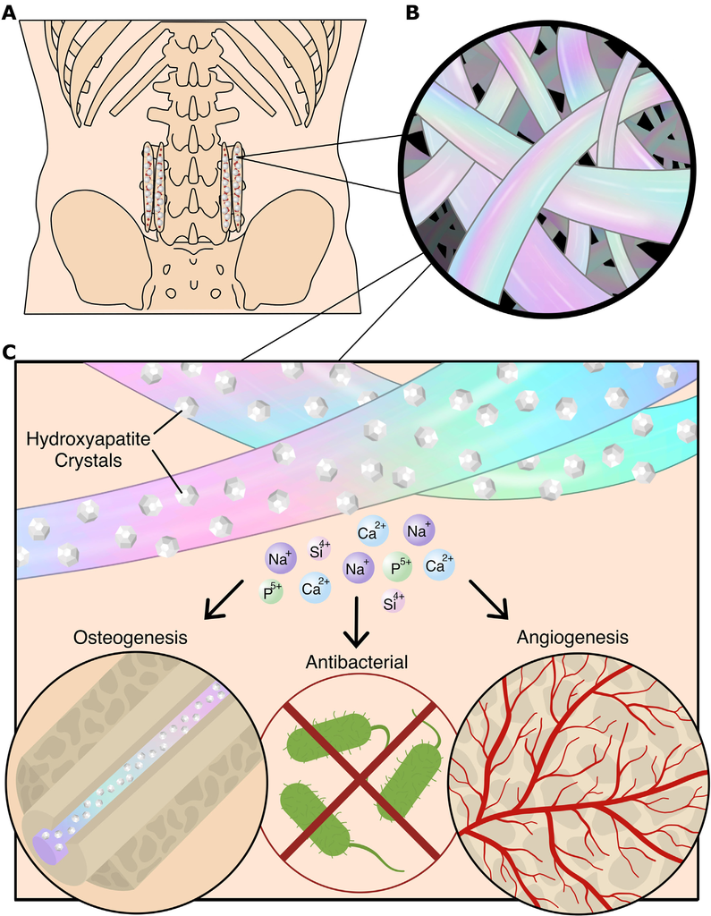

Fig. 1. Conceptual illustration of the effect of bioactive glasses on spinal fusion. A: Posterolateral L3-5 inter-transverse process spinal fusion using autologous bone graft

mixed with bioactive glass particles. B: Magniﬁed representation of bioactive glass ﬁbers. C: Primary mechanisms of action of bioactive glasses on spinal fusion – including

bone formation, antibacterial activity, and vascular formation – mediated by the release of ions from the bioactive glass into the surrounding environment as well as the

surface chemistry and topography of the glass structure (see Table 1).

E. Cottrill et al. / Journal of Clinical Neuroscience xxx (xxxx) xxx

3

Eleven of the twelve preclinical studies reported fusion rates for

animals treated with bioactive glass, with a mean fusion rate of

58% (95% CI 38–76%; I<sup>2</sup>= 84.2%; range 0–100%, Fig. 3). Six of the

studies compared bioactive glass-containing bone grafts to auto-

graft [41,43,44,47,49,51]. Among these six, mean fusion rate for

animals treated with bioactive glass was 46.9% (95% CI 17.1–

78.0%; I<sup>2</sup>= 91.1%) compared to 72.3% (95% CI 46.7–91.8%;

I<sup>2</sup>= 71.1%) for animals treated with autograft alone. This difference

was not statistically signiﬁcant (OR 0.41 [95% CI 0.08–2.05],

p > 0.05).

3.1.2. Clinical data

Of the 12 clinical studies, one included pediatric patients only,

nine included adult patients only, and two reported results from

a mixed pediatric-adult cohort. Surgeries comprised a combination

of single- and multi-level procedures following posterior, postero-

lateral and/or interbody techniques (Table 3). With the exception

of Barrey et al., who evaluated cervical and lumbar fusion proce-

dures [54], all studies investigated bioactive glasses in thoracolum-

bar spine surgeries. A total of ﬁve unique bioactive glasses were

investigated (Table 3).

Across all studies, the mean fusion rate for patients treated with

bioactive glass bone grafts was 84% (95% CI 68–95%; I<sup>2</sup>= 90.6%;

range 4–100%; Fig. 3). Within the seven studies directly comparing

bioactive glass to autograft [16,17,52,53,55,58,60], mean fusion

rate was 75.3% for patients treated with bioactive glasses (95% CI

45.9–95.6%; I<sup>2</sup>= 94%) and 94.2% for patients treated with

autograft-alone (95% CI 89.4–97.7%; I<sup>2</sup>= 20.9%). As with the animal

literature, these differences were not statistically signiﬁcant (OR

0.29 [95% CI 0.05–1.79], p > 0.05).

3.2. Effect by type of bioactive glass

Sub-analyses using random-effects modeling were performed

for each of the 12 unique bioactive glasses, with mean fusion rates

provided in Table 4. Interestingly, preclinical and clinical data were

found only for three types of bioactive glass: S53P4, AW-GC, and

45S5. Among the preclinical studies, the fusion rate ranged from

0% (95% CI 0–28.5%) for P10B90 to 90.9% (95% CI 58.7–99.8%) for

CSPB3. In the clinical studies, the fusion rate ranged from 4.5%

(95% CI 0–22.8%) for Chitra-HABg to 94.6% (95% CI 86.2–99.2%)

for AW-GC. Successful fusion was seen in 93.9% (95% CI 88.1–

97.9%) of cases for the archetypal 45S5 formulation.

3.3. Subgroup meta-analysis of the clinical data

The included literature reported use of bioactive glasses both as

a standalone substrate and as part of a bone graft-bioactive glass

composites. Consequently, we preformed sub-analyses of fusion

rate by bioactive glass usage and fusion technique for the seven

clinical studies that directly compared bioactive glass-containing

bone grafts to autograft by type of usage (Table 5). Across all stud-

ies, successful fusion was achieved in 89.6% of cases (95% CI 76.6–

97.7%) when bioactive glass was mixed with local autograft, com-

pared to 91.6% of patients (95% CI 86.0–95.9%) fused with autograft

alone. This difference was not statistically signiﬁcant (OR 1.11 [95%

CI 0.38–3.26]; p > 0.05). By comparison, when bioactive glass was

used as a standalone substrate, inferior fusion rates were seen rel-

ative to autograft alone (33.6% vs. 98.8%; OR 0.01 [95% CI 0.01–

0.24]; p < 0.02).

With regard to the secondary endpoint, deep wound infection

rates were reported in eight of the 12 clinical studies [16,17,53–

56,59,60]. Deep wound infections were seen in 3.1% of patients

treated with bioactive glass (95% CI 1.1–5.9%; I<sup>2</sup>= 0%). Five of these

8 studies reported infection rates for both bioactive glass and auto-

graft groups [16,17,53,55,60]; wound infections were seen in 3.1%

of patients treated with bioactive glass (95% CI 0.7–7.3%; I<sup>2</sup>= 0%)

and 3.1% (0.6–7.4%; I<sup>2</sup>= 0%) of those treated with autograft alone.

This difference was not statistically signiﬁcant (OR: 0.81 [95% CI

0.15–4.40]; p > 0.05).

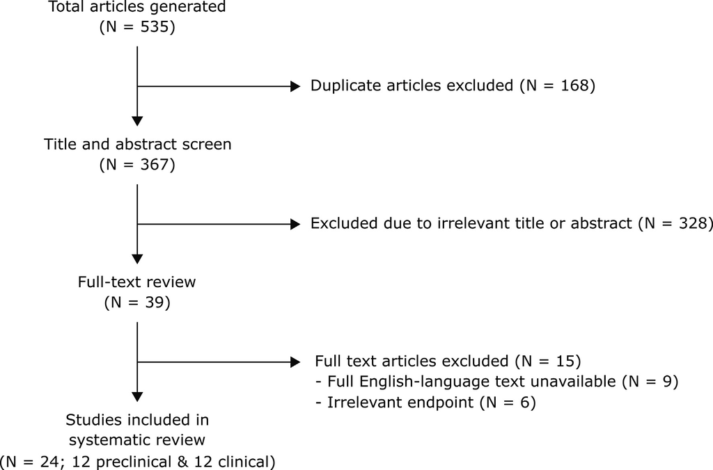

Fig. 2. Diagram of the consolidated standards of reporting trials for article selection.

4

E. Cottrill et al. / Journal of Clinical Neuroscience xxx (xxxx) xxx

Table 2

Descriptive summaries of the identiﬁed preclinical studies (n = 12).

Author, Year,

(LOE)*

Animal (n); Surgical Model

Study Groups (n)y

Deﬁnition of Fusion Outcome

Fusion Rate (n fused/n total)

Lindfors et al.,

2000 (V)

Rabbit (n = 8); one or two one-level thoracic posterior (spinous

process and facet joint) fusion with either (a) bioactive glass, (b)

bioactive glass/iliac crest autograft mixture (70/30 by volume), or

(c) iliac crest autograft

A. S53P4 bioactive glass (630–800 mm)

(n = 4)

N/A

Fusion rate was not reported; however, by

12 weeks, no signiﬁcant difference in

bone formation between the three groups

was observable.

B. S53P4 bioactive glass (630–800 mm)/

iliac crest autograft mixture (70/30 by

volume) (n = 4)

C. Iliac crest autograft (n = 4)

Lindfors et al.,

2002 (V)

Rabbit (n = 12); two one-level thoracolumbar posterior (spinous

process and facet joint) fusion with either (a) bioactive glass, (b)

bioactive glass/iliac crest autograft mixture (70/30 by volume), or

(c) iliac crest autograft

A. S53P4 bioactive glass (630–800 mm)

(n = 4)

Computed tomographic (CT) evidence of

bony union, deﬁned as a continuous fusion

mass consolidated to both vertebrae at

12 weeks post-operatively

A. 75% (3/4)

B. S53P4 (630–800 mm)/iliac crest

autograft mixture (70/30 by volume)

(n = 4)

B. 75% (3/4)

C. Iliac crest autograft (n = 4)

C. 50% (2/4)

Lee et al., 2005

(V)

Rabbit (n = 41); L5–6 posterolateral inter-transverse process fusion

with (a) porous bioactive glass, prepared via the polymer sponge

method, or (b) iliac crest autograft

A. CSPB2 bioactive glass (n = 11)

Fusion via manual palpation at 12 weeks

post-operatively

A. 81.1% (9/11)

B. CSPB3 bioactive glass (n = 11)

B. 90.9% (10/11)

C. AW-GC bioactive glass (Cerabone�)

(n = 10)

C. 80% (8/10)

D. Iliac crest autograft (n = 9)

D. 100% (9/9)

Takahata et al.,

2005 (V)

Sheep (n = 4); L2-L3 and L4-L5 anterior lumbar interbody fusion

using either a smooth or porous surface AW-GC bioactive glass

ceramic interbody device and a one-rod anterior spinal

instrumentation system (Kaneda-Smooth Rod)

A. Smooth surface AW-GC bioactive

glass ceramic interbody device (n = 4)

Radiographic evidence of fusion, deﬁned as

continuous bridging bone formation between

the vertebral bodies, at 52 weeks post-

operatively

A. 100% (4/4)

B. Porous surface AW-GC bioactive glass

ceramic interbody device (n = 4)

B. 100% (4/4)

Lee et al., 2006

(V)

Rabbit (n = 24); L5–6 posterolateral inter-transverse process fusion

with (a) bioactive glass, (b) hydroxyapatite, or (c) tricalcium

phosphate

A. CS10B bioactive glass (3–4 mm) (n = 8)

Absence of motion by manual palpation at

12 weeks post-operatively

A. 62.5% (5/8)

B. Hydroxyapatite (n = 8)

B. 75% (6/8)

C. Tricalcium phosphate (n = 8)

C. 37.5% (3/8)

Lee et al., 2014

(V)

Rabbit (n = 43); L5–6 posterolateral inter-transverse process fusion

with bioactive glass or iliac crest autograft

A. P20B80 bioactive glass (n = 17)

Immobility to twisting, bending, and folding

motions by manual palpation at 12 weeks

post-operatively

A. 29.4% (5/17)

B. P10B90 bioactive glass (n = 11)

B. 0% (0/11)

C. P5B95 bioactive glass (n = 7)

C. 14.3% (1/7)

D. Iliac crest autograft (n = 8)

D. 100% (8/8)

Smucker et al.,

2015 (V)

Rabbit (n = 45); L5–6 posterolateral inter-transverse process fusion

with (a) Vitoss BA, (b) Actifuse ABX, (c) SiCaP-30, or (d) iliac crest

autograft

A. Vitoss BA (beta-tricalcium phosphate,

bovine Type I collagen, and 45S5

bioactive glass [20% by weight; 32–150

mm]) (n = 11)

Absence of motion via manual palpation at

12 weeks post-operatively

A. 0% (0/11)

B. Actifuse ABX (porous silicon-

substituted hydroxyapatite [portion of

the phosphate groups, PO4, are replaced

with silicate, SiO4]; 0.8 wt% Si) (n = 12)

B. 33% (4/12)

C. SiCaP-30 (porous silicon-substituted

hydroxyapatite [portion of the

phosphate groups, PO4, are replaced

with silicate, SiO4]; 0.8 wt% Si) (n = 11)

C. 82% (9/11)

D. Iliac crest autograft (n = 11)

D. 45% (5/11)

Fredericks

et al., 2016

(V)

Rabbit (n = 20); L5–6 posterolateral inter-transverse process fusion

with (a) Signafuse Bioactive Bone Graft Putty or (b) Actifuse ABX

A. Signafuse Bioactive Bone Graft Putty

(biphasic calcium phosphate [60%

hydroxyapatite and 40% beta-tricalcium

phosphate; 1–2 mm granules] and 45S5

bioactive glass [212–420 mm]

suspended in a resorbable alkylene

oxide polymer matrix) (n = 10)

Absence of motion via manual palpation at

12 weeks post-operatively

A. 50% (5/10)

B. Actifuse ABX (porous silicon-

substituted hydroxyapatite [portion of

the phosphate groups, PO4, are replaced

with silicate, SiO4]; 0.8 wt% Si) (n = 10)

B. 50% (5/10)

(continued on next page)

E. Cottrill et al. / Journal of Clinical Neuroscience xxx (xxxx) xxx

5

Table 2 (continued)

Author, Year,

(LOE)*

Animal (n); Surgical Model

Study Groups (n)y

Deﬁnition of Fusion Outcome

Fusion Rate (n fused/n total)

Shiels et al.,

2017 (V)

Rabbit (n = 6); L5–6 posterolateral inter-transverse process fusion

with an injected polymer (ester urethane)/composite bone graft

comprising rhBMP-2 and (a) bioactive glass or (b) Mastergraft Mini

Granules

A. Polyester urethane composite bone

graft comprising rhBMP-2 and 45S5

bioactive glass (n = 3)

Absence of motion via manual palpation at

8 weeks post-operatively

A. 100% (3/3)

B. Polyester urethane composite bone

graft comprising rhBMP-2 and

Mastergraft Mini Granules (85% beta-

tricalcium phosphate and 15%

hydroxyapatite) (n = 3)

B. 100% (3/3)

Pugely et al.,

2017 (V)

Rabbit (n = 26); L5–6 posterolateral inter-transverse process fusion

with either (a) iliac crest autograft, bone marrow aspirate, and Bi-

Ostetic; (b) iliac crest autograft, bone marrow aspirate, and

Formagraft; or (c) iliac crest autograft alone

A. Bi-Ostetic (bovine Type I collagen,

biphasic calcium phosphate [60%

hydroxyapatite and 40% beta-tricalcium

phosphate], and 45S5 bioactive glass

granules) mixed with iliac crest

autograft and bone marrow aspirate

(n = 9)

Absence of motion via manual palpation at

12 weeks post-operatively

A. 56% (5/9)

B. Formagraft (bovine Type I collagen

and biphasic calcium phosphate [60%

hydroxyapatite and 40% beta-tricalcium

phosphate]) mixed with iliac crest

autograft and bone marrow aspirate

(n = 9)

B. 56% (5/9)

C. Iliac crest autograft alone (n = 8)

C. 50% (4/8)

Khoshakhlagh

et al., 2017

(V)

Rat (n = 8); L4–L5 posterolateral inter-transverse process fusion

with an injected bioactive glass (BG)/chitosan composite bone graft

Composite bone graft

comprising chitosan

and BG bioactive glass

A. 50% BG

bioactive

glass, by

weight

(n = 4)

Absence of motion via manual palpation at

8 weeks post-operatively

A. 75% (3/4)

B. 70% BG

bioactive

glass, by

weight

(n = 4)

B. 100% (4/4)

Ke et al., 2018

(V)

Rabbit (n = 30); L5–L6 interbody fusion with a 3-D printed

bioceramic cage or iliac crest autograft

3-D printed cage

comprising akermanite

(Ca2MgSi2O7) and 45S5

bioactive glass

A. 0% 45S5

bioactive

glass (n = 6)

Absence of motion via manual palpation at

12 weeks post-operatively

A. 0% (0/6)

B. 15% 45S5

bioactive

glass (n = 6)

B. 67% (4/6)

C. 30% 45S5

bioactive

glass (n = 6)

C. 67% (4/6)

D. 3-D printed beta-tricalcium

phosphate cage (n = 6)

D. 17% (1/6)

E. Iliac crest autograft (n = 6)

E. 67% (4/6)

*Levels of evidence (LOE) classiﬁed according to guidelines of the North American Spine Society.

yChemical formulation (weight %) of investigated bioactive glasses in preclinical studies:

1. S53P4: 53% SiO2, 23% Na2O, 20% CaO, 4% P2O5

2. CSPB2: 44.07% CaO, 40.28% SiO2, 8.1% P2O5, 5.0% B2O3

3. CSPB3: 43.76% CaO, 43.41% SiO2, 4.05% P2O5, 7.5% B2O3

4. AW-GC (apatite- and wollastonite-containing glass ceramic): 44.9% CaO, 34.2% SiO2, 16.3% P2O5, 4.6% MgO, 0.5% CaF2

5. CS10B: 45.7% CaO, 45.7% SiO2, 8.6% B2O3

6. P20B80: 45.54% CaO, 43.40% SiO2, 3.26% P2O5, 8.00% B2O3, 0.92% MgO, 0.10% CaF2

7. P10B90: 43.57% CaO, 45.30% SiO2, 1.62% P2O5, 9.00% B2O3, 0.46% MgO, 0.05% CaF2

8. P5B95: 43.51% CaO, 45.92% SiO2, 0.81% P2O5, 9.50% B2O3, 0.23% MgO, 0.025% CaF2

9. BG: 64% SiO2, 31% CaO, 5% P2O5

10. 45S5: 45% SiO2, 24.5% Na2O, 24.5% CaO, 6% P2O5

6

E. Cottrill et al. / Journal of Clinical Neuroscience xxx (xxxx) xxx

Table 3

Descriptive summaries of the identiﬁed clinical studies (n = 12).

Author, Year,

Study Design,

(LOE)*

Inclusion Criteria

Surgical Model

Study Groupsy (no. of pts)

Deﬁnition of Fusion Outcome

Fusion

Rate (n

fused/

n total)

Deep

Wound

Infection

Rate

(pts)�

Kaneda et al.,

1992,

retrospective

case series

(IV)

Adult patients with neurological deﬁcit due to

delayed post-traumatic vertebral body collapse

after osteoporotic compression fractures of the

thoracolumbar spine undergoing anterior

decompression and reconstruction with Kaneda

instrumentation, autologous rib strut graft, and

bioactive glass

Anterior decompression and reconstruction with

Kaneda instrumentation, autologous rib strut

graft, and AW-GC bioactive glass vertebral

prosthesis

All patients received AW-GC

bioactive glass vertebral

prosthesis and autologous

rib strut graft (n = 20)

Radiographic evidence of fusion with

osseointegration and consolidation of the

AW-GC vertebral prosthesis at 24 months

post-operatively

95%

(19/

20)

N/A

Ido et al., 2000,

retrospective

case series

(IV)

Adult patients with degenerative or traumatic

indications undergoing instrumented single- or

multi-level posterolateral lumbar fusion, with or

without posterior lumbar interbody fusion, using

porous sticks of apatite- and wollastonite-

containing glass ceramic (AW-GC) mixed with

autologous bone graft.

Instrumented posterolateral lumbar fusion, with

or without posterior lumbar interbody fusion,

using porous sticks of AW-GC bioactive glass

mixed with autologous bone graft.

All patients received AW-GC

bioactive glass (porous stick

type) mixed with local

autologous bone graft (n = 6)

Plain-ﬁlm radiographic evidence of

‘‘subtotal” or ‘‘total” fusion, with a change

in the conﬁguration and/or density of > 2/3

of the implanted AW-GC bioactive glass, at

24 months post-operatively.

100%

(6/6)

N/A

Hashimoto et al.,

2002,

retrospective

case series

(IV)

Pediatric and adult patients with back and/or leg

pain undergoing one-level posterior lumbar

interbody fusion using spinal instrumentation

and the Brantigan I/F cage ﬁlled with a mixture of

local autograft and AW-GC bioactive glass

One-level posterior lumbar interbody fusion

using spinal instrumentation (e.g., Steffee

Variable Screw Placement pedicle screw system)

and the Brantigan I/F cage ﬁlled with a mixture of

local autograft and AW-GC bioactive glass

All patients received a

Brantigan I/F cage ﬁlled with

a mixture of local autograft

and AW-GC bioactive glass

granules (n = 25)

Radiographic evidence of fusion, deﬁned as

continuous bridging bone across the disc

space, at a minimum of 24 months post-

operatively

100%

(25/

25)

0% (0/25)

Kasai et al.,

2003,

prospective,

matched,

randomized

(II)

Adult patients with lumbar spinal canal stenosis

undergoing two-level, non-instrumented

posterolateral lumbar fusion with one of three

ratios of bioactive glass and local autograft

Two-level, non-instrumented posterolateral

lumbar fusion

Mixture of bone

graft in different

ratios (local

autograft to AW-

GC bioactive

glass)

A. 2:1

(n = 12)

Radiographic evidence of fusion at 2 years

post-operatively

A.

83.3%

(10/

12)

A. 0%

(0/12)

B. 1:1

(n = 12)

B.

83.3%

(10/

12)

B. 0%

(0/12)

C. 1:2

(n = 11)

C.

81.8%

(9/11)

C. 0%

(0/11)

Ilharreborde

et al., 2008,

retrospective

comparative

cohort (III)

Pediatric patients with progressive thoracic

adolescent idiopathic scoliosis undergoing

posterior spinal fusion with (a) autograft mixed

with bioactive glass or (b) autograft alone

Multi-level posterior spinal fusion using

segmental ﬁxation with hybrid instrumentation

(pedicle screws at lumbar levels and hooks at

thoracic levels) and either (a) autograft mixed

with bioactive glass or (b) autograft alone

A. 45S5 bioactive glass

(Bioglass; Novabone) mixed

with local autograft (n = 48)

Radiographic evidence of fusion

(‘‘mechanical failure” deﬁned as

pseudarthrosis), at a 2-year minimum

follow-up

A. 98%

(47/

48)

A. 2%

(1/48)

B. Local and iliac crest

autograft (n = 40)

B.

92.5%

(37/

40)

5% (2/40)

Acharya et al.,

2008,

prospective,

matched,

controlled (II)

Adult patients undergoing single- or multi-level

instrumented posterolateral lumbar fusion for

spondylolisthesis or degenerative indications

with Chitra-HABg bioactive glass and bone

marrow aspirate (left side of fusion bed) and local

autologous bone (right side of fusion bed)

Single- or multi-level instrumented

posterolateral lumbar fusion with Chitra-HABg

bioactive glass and bone marrow aspirate (left

side of fusion bed) and local autologous bone

(right side of fusion bed)

A. Chitra-HABg bioactive

glass (80% hydroxyapatite

and 20% bioactive glass

[composition unknown])

plus bone marrow aspirate

on the left side of the fusion

bed (n = 22)

Radiographic evidence of fusion at 12-

months follow-up; independent

assessment of left and right sides of fusion

beds

A. 5%

(1/22)

N/A

B. Locally harvested

autograft (lamina and

spinous process) on the right

side of the fusion bed

(n = 22; same patients as

above)

B.

100%

(22/

22)

Ameri et al.,

2009,

retrospective

Pediatric and adult patients with adolescent

idiopathic scoliosis undergoing posterior fusion

using local autograft and either (a) 45S5 bioactive

Posterior fusion (Cotrel and Dubousset

technique) using local autograft and either (a)

45S5 bioactive glass or (b) iliac crest autograft

A. Local autograft and 45S5

bioactive glass (NovaBone);

size 90–710 mm (n = 20)

Radiographic evidence of fusion, deﬁned as

a solid fusion mass without evidence of

halo around the implants, at a minimum of

A. 90%

(18/

20)

5% (1/20)

(continued on next page)

E. Cottrill et al. / Journal of Clinical Neuroscience xxx (xxxx) xxx

7

Table 3 (continued)

Author, Year,

Study Design,

(LOE)*

Inclusion Criteria

Surgical Model

Study Groupsy (no. of pts)

Deﬁnition of Fusion Outcome

Fusion

Rate (n

fused/

n total)

Deep

Wound

Infection

Rate

(pts)�

comparative

cohort (IV)

glass or (b) iliac crest autograft

24 months post-operatively

B. Local autograft and iliac

crest autograft (n = 20)

B. 85%

(17/

20)

0% (0/20)

Kanayama et al.,

2010,

retrospective

case series

(IV)

Adult patients with single- or multi-level

osteoporotic vertebral collapse and neurological

deﬁcits undergoing anterior spinal reconstruction

(Kaneda instrumentation), with or without

posterior reinforcement, and anterior column

support using either (a) AW-GC bioactive glass

ceramic and rib strut graft, (b) cylindrical

titanium cage and rib strut graft, or (c) iliac crest

autograft and rib strut graft

Anterior spinal reconstruction using Kaneda

anterior instrumentation for osteoporotic

vertebral collapse, with or without posterior

reinforcement, and anterior column support

using either (a) AW-GC bioactive glass ceramic

and rib strut graft, (b) cylindrical titanium cage

and rib strut graft, or (c) iliac crest autograft and

rib strut graft

A. Anterior column support

using AW-GC bioactive glass

ceramic spacer and rib strut

graft (n = 18)

Radiographic evidence of fusion, deﬁned as

solid bone formation, at a mean of

57 months post-operatively (minimum

follow-up not reported)

A.

100%

(18/

18)

N/A

B. Anterior column support

using cylindrical titanium

cage and rib strut graft

(n = 12)

B.

100%

(12/

12)

C. Anterior column support

using iliac crest autograft

and rib strut graft (n = 1)

C.

100%

(1/1)

Frantzén et al.,

2011,

prospective,

matched,

controlled (II)

Adult patients with degenerative lumbar

spondylolisthesis undergoing instrumented

posterolateral lumbar fusion with bioactive glass

(left side of fusion bed) and autograft (right side

of fusion bed)

Instrumented posterolateral lumbar fusion using

bioactive glass (left side of fusion bed) and

autograft (right side of fusion bed)

A. S53P4 bioactive glass (left

side of fusion bed) (n = 17)

Computed tomographic evidence of solid

fusion at 11-years follow-up; independent

assessment of left and right sides of fusion

beds

A.

70.6%

(12/

17)

A. 0%

(0/17)

B. Locally harvested

autograft (lamina) and iliac

crest autograft (right side of

fusion bed) (n = 17; same

patients as above)

B.

100%

(17/

17)

B. 0%

(0/17)

Rantakokko

et al., 2012,

prospective,

matched,

controlled (II)

Adult patients with unstable thoracolumbar burst

fractures undergoing instrumented posterolateral

fusion with local autograft mixed with bioactive

glass (left side of fusion bed) and autograft alone

(right side of fusion bed)

Instrumented posterolateral lumbar fusion using

local autograft mixed with bioactive glass (left

side of fusion bed) and autograft alone (right side

of fusion bed)

A. S53P4 bioactive glass

mixed with local autograft

(left side of fusion bed)

(n = 10)

Computed tomographic evidence of solid

fusion at 10-years follow-up; independent

assessment of left and right sides of fusion

beds

A. 50%

(5/10)

A. 0%

(0/10)

B. Local and iliac crest

autograft (right side of fusion

bed) (n = 10; same patients

as above)

B.

100%

(10/

10)

B. 0% (0/

10)

Lee et al., 2016,

prospective,

randomized,

multi-center

case control

study (II)

Adult patients with lumbar spinal stenosis,

spondylolisthesis, or disc herniation undergoing

one-level posterior lumbar interbody fusion with

local autograft and either (a) bioactive glass

ceramic spacer or (b) titanium cage

Posterior lumbar interbody fusion with pedicle

screws and rod using local autograft bone and

either (a) bioactive glass ceramic spacer or (b)

titanium cage

A. BGS-7 bioactive glass

ceramic interbody spacer

(NovoMax) and local

autograft (n = 39)

Computed tomographic evidence of fusion

at 12 months post-operatively

A.

89.7%

(35/

39)

A. 0%

(0/10)

B. Local autograft and

titanium interbody cage

ﬁlled with local autograft

(n = 34)

B.

91.2%

(31/

34)

B. 0%

(0/10)

Barrey et al.,

2019,

retrospective

case series

(IV)

Adult patients with spinal degeneration,

traumatic injury, and/or deformity undergoing

instrumented cervical or lumbar posterior spinal

fusion with bioactive glass and local autograft

Instrumented cervical or lumbar posterior spinal

fusion with bioactive glass and local autograft

All patients received 45S5

bioactive glass (GlassBone)

mixed with local autograft

(1:1 vol ratio) (n = 29)

Computed tomographic evidence of fusion

at a minimum of 12 months post-

operatively

93%

(27/

29)

10%

(3/29)

*Levels of evidence (LOE) classiﬁed according to guidelines of the North American Spine Society.

yChemical formulation (weight %) of investigated bioactive glasses in clinical studies:

1. AW-GC (apatite- and wollastonite-containing glass ceramic): 44.9% CaO, 34.2% SiO2, 16.3% P2O5, 4.6% MgO, 0.5% CaF2

2. 45S5: 45% SiO2, 24.5% Na2O, 24.5% CaO, 6% P2O5

3. Chitra-HABg: composition unknown

4. S53P4: 53% SiO2, 23% Na2O, 20% CaO, 4% P2O5

5. BGS-7: 41.79% CaO, 35.82% SiO2, 13.93% P2O5, 5.97% MgO, 1.99% CaF2, 0.5% B2O3

� Surgical site infections not described as superﬁcial were deﬁned as deep wound infections; if the infection rate was not indicated, N/A was recorded.

8

E. Cottrill et al. / Journal of Clinical Neuroscience xxx (xxxx) xxx

4. Discussion

Some 400,000 Americans undergo spinal fusion procedures

annually with cumulative costs estimated at $13 billion [1,2].

While

most

patients

experience

symptomatic

improvement,

20–30% experience nonunion [61,62], which has been correlated

with poorer clinical outcomes [3–5]. For this reason, there is great

interest

in

developing

surgical

techniques

and

biomaterials

capable of improving fusion rates. Here we examine one such

biomaterial class – bioactive glasses – and provide the systematic

review of the preclinical and clinical literature. Our analysis

included 12 preclinical and 12 clinical studies evaluating 12 unique

bioactive glass formulations. Mean fusion rate was 58% for the

preclinical studies and 84% for the clinical studies, with high vari-

ability noted across the bioactive glass types. Analysis of those

clinical studies directly comparing bioactive glass constructs with

standalone autograft showed no signiﬁcant difference in fusion

rate. This ﬁnding remained identical on sub-analysis comparing

autograft to bioactive glass-bone graft composite (91.6% vs

89.6%; p > 0.05); however, comparison of autograft with stan-

dalone bioactive glass showed signiﬁcantly lower fusion rates in

the group treated with bioactive glass alone (33.6% vs. 98.8%;

OR 0.01 [95% CI 0.01–0.24]; p < 0.02). We saw no signiﬁcant

difference in deep wound infection rates between autograft and

bioactive glass-treated patients (3.1% vs 3.1%; p > 0.05).

It is widely agreed upon that long-term stability of fusion con-

structs is contingent upon achieving bony fusion across the fused

segments. Numerous options exist for reconstruction, including

local autograft, cadaveric allograft, and bone graft substitutes.

Local autograft is a preferred substrate for fusion as it eliminates

the theoretical risk of rejection, has lower complication rates than

iliac crest graft, and provides superior fusion outcomes relative to

cadaveric allograft [63–66]. However, local autograft is often lim-

ited and may be insufﬁcient to cover the length of the entire con-

struct. Consequently, there has been great investment in the

development of bone graft substitute materials, such as calcium

phosphate-based materials and bioactive glasses. These materials

carry with them the potential to extend native bone graft and

may have greater usable shelf lives relative to cadaveric allograft.

It is in this role that the present data support the use of bioac-

tive glasses. Though we ﬁnd that fusion rates are inferior in con-

structs employing bioactive glass as a monotherapy relative to

those employing native bone, constructs utilizing amalgams of

bioactive glass and autograft result in similar rates of arthrodesis.

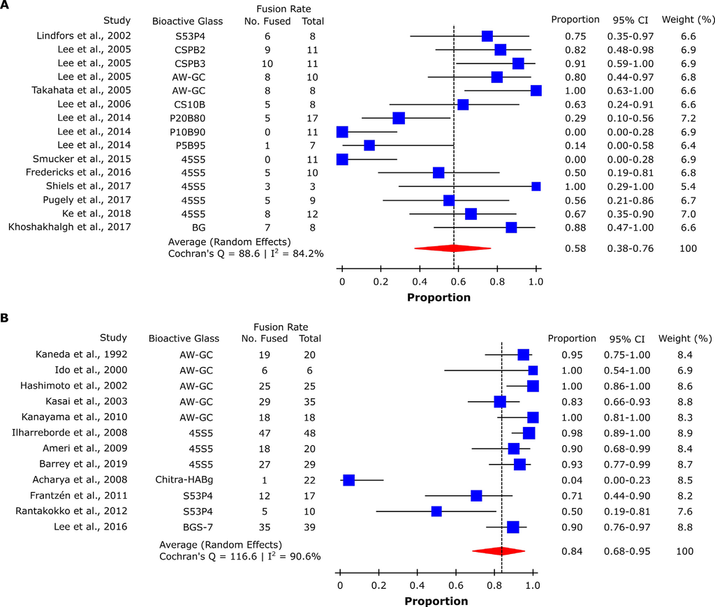

Fig. 3. Forest plots demonstrating random-effects meta-analyses of the fusion rates from the available A) pre-clinical studies (58% [95% CI 38–76%]) and B) clinical studies

(84% [95% CI 68–95%]) evaluating the effect of bioactive glasses on spinal fusion.

E. Cottrill et al. / Journal of Clinical Neuroscience xxx (xxxx) xxx

9

Consequently, the evidence suggests that in cases where there is

insufﬁcient autograft to cover the complete construct, a composite

of bioactive glass and native autograft may result in arthrodesis

outcomes comparable to a construct fused solely with autograft.

This role is further supported by consideration of the composition

of bioactive glasses, which are completely devoid of the growth

factors and osteoprogenitor cells that give rise to the osteoinduc-

tive properties of host bone.

In this osteoconductive role, however, we do note signiﬁcant

variability in the efﬁcacy of the available bioactive glasses. As all

bioactive glasses employ a core of silicon dioxide and calcium

oxide, the observed variation in osteoconductive abilities likely

stems from the unique properties of the glass, which are dictated

by the other constituent ion dopants and surface topography.

Given the relative novelty of bioactive glasses in the commercial

setting, though, the exact topography and combination of dopants

that produce the greatest osteoconductivity remain unknown.

Investigations into this topic continue. It is possible that a better

capture of the means by which these properties are created will

result in novel bioactive glass formulations capable of being

employed without intermixed autograft [22,67].

As with any new technology, evaluating the utility of bioactive

glasses for spinal fusion is predicated upon demonstrating that

they are at least equivalent to currently available alternatives,

which in this case comprise other commercially available bone

graft substitute materials (e.g., calcium phosphate-based, calcium

sulfate-based, and demineralized bone matrices). Unfortunately,

it is near-impossible for us to evaluate this endpoint at present

given the absence of prior comparisons of fusion rates in constructs

employing bioactive glasses or other graft substitutes. However,

initial impressions can be gleaned by comparing the fusion rates

seen in the present study to those documented in prior reports of

fusion rates for constructs employing other commercially available

bone graft substitutes. To this end, a 2014 systematic review

reported a mean fusion rate in lumbar spine arthrodesis of 92.5%

for beta-tricalcium phosphate (345 total patients across 7 studies),

86.7% for calcium sulfate (353 total patients across 6 studies), and

83.6% for biphasic beta-tricalcium phosphate/hydroxyapatite (152

patients across 4 studies) [68]. Similarly, a 2018 systematic review

reported a mean fusion rate in lumbar spine arthrodesis across four

studies of 81.2% for local autograft combined with demineralized

bone matrix [15]. In both cases, the reported fusion rates are sim-

ilar to the rate we saw for constructs incorporating bioactive glass

employing other, commercially available graft substitutes. Future

studies are needed to evaluate the cost-effectiveness of bone graft

substitute materials in spinal fusion.

Table 4

Mean fusion rates of bone grafts comprising bioactive glasses in preclinical and clinical studies determined by random-effects meta-analysis.

Type of Bioactive Glass

Authors & Year

Fusion Rate (no. fused/total)*

Preclinical

Clinical

S53P4

Lindfors et al., 2002

6/8

–

Frantzén et al., 2011

–

12/17

Rantakokko et al., 2012

–

5/10

Overall (95% CI); I<sup>2</sup>

75% (34.9–96.8%)

62.1% (43.1–79.3%); 8.6%

CSPB2

Lee et al., 2005

9/11

–

Overall (95% CI); I<sup>2</sup>

81.8% (48.2–97.8%)

–

CSPB3

Lee et al., 2005

10/11

–

Overall (95% CI); I<sup>2</sup>

90.9% (58.7–99.8%)

–

AW-GC

Lee et al., 2005

8/10

–

Takahata et al., 2005

8/8

–

Kaneda et al., 1992

–

19/20

Ido et al., 2000

–

6/6

Hashimoto et al., 2002

–

25/25

Kasai et al., 2003

–

29/35

Kanayama et al., 2010

–

18/18

Overall (95% CI); I<sup>2</sup>

88.9% (62.6–99.9%); 52.2%

94.6% (86.2–99.2%); 55.5%

CS10B

Lee et al., 2006

5/8

–

Overall (95% CI); I<sup>2</sup>

62.5% (24.5–91.5%)

–

P20B80

Lee et al., 2014

5/17

–

Overall (95% CI); I<sup>2</sup>

29.4% (10.3–60.0%)

–

P10B90

Lee et al., 2014

0/11

–

Overall (95% CI); I<sup>2</sup>

0% (0–28.5%)

–

P5B95

Lee et al., 2014

1/7

–

Overall (95% CI); I<sup>2</sup>

14.3% (3.6–57.9%)

–

45S5

Smucker et al., 2015

0/11

–

Fredericks et al., 2016

5/10

–

Shiels et al., 2017

3/3

–

Pugely et al., 2017

5/9

–

Ke et al., 2018

8/12

–

Ilharreborde et al., 2008

–

47/48

Ameri et al., 2009

–

18/20

Barrey et al., 2019

–

27/29

Overall (95% CI); I<sup>2</sup>

49.6% (17.4–82.0%); 83.8%

93.9% (88.1–97.9%); 9.15%

BG

Khoshakhlagh et al., 2017

7/8

–

Overall (95% CI); I<sup>2</sup>

87.5% (47.4–99.7%)

–

Chitra-HABg

Acharya et al., 2008

–

1/22

Overall (95% CI); I<sup>2</sup>

–

4.5% (0–22.8%)

BGS-7

Lee et al., 2016

–

35/39

Overall (95% CI); I<sup>2</sup>

–

89.7% (75.8–97.1%)

All (95% CI); I<sup>2</sup>

57.6% (38.0–76.0%); 84.2%

84.0% (68.2–95.1%); 90.6%

*For single proportions, 95% conﬁdence intervals (95% CI) were determined via exact binomial limits.

10

E. Cottrill et al. / Journal of Clinical Neuroscience xxx (xxxx) xxx

4.1. Study limitations

There are several limitations to this study. First, our clinical data

meta-analyses rely upon heterogeneous data culled from a combi-

nation of prospective and retrospective studies of varying quality.

Consequently, the present results are at best as good as the lowest

quality study that was included, making the present study level IV

evidence. It is therefore unknown whether the present results can

be generalized to all spine patients. The limited available data sim-

ilarly prevented us from analyzing bioactive glasses by particle

size, architecture, or ion dopants, which could inform future

materials-based research directions. Additionally, the included

studies employed different methods for assessing bony fusion,

which imparts heterogeneity to the results and limits our ability

to compare the efﬁcacy of bioactive glasses to other commercially

available bone graft substitutes. We attempt to address this

heterogeneity by describing the method and deﬁnition of fusion

assessment for each included study and by using a random-

effects versus ﬁxed-effects model during our analysis. Given these

limitations, though, it is apparent that additional, high-quality

research is needed to more fully evaluate the efﬁcacy – and cost-

effectiveness – of bioactive glasses on spinal fusion.

5. Conclusions

Here we report the ﬁrst systematic review and meta-analysis of

the effect of bioactive glasses on spinal fusion across the preclinical

and clinical literature. We found that when mixed with local auto-

graft, bioactive glasses yield similar rates of spinal fusion com-

ever, when used in isolation, bioactive glasses yield inferior fusion

rates relative to autograft alone. Similar ﬁndings were observed in

the animal literature, suggesting that these models are translatable

Table 5

Results from random-effects meta-analyses of mean fusion rates and odds ratios from the available clinical data in aggregate and in subgroups.*

Variable

Authors & Year

Type of

Bioactive Glass

Fusion Rate (no. fused/total)

Q<sup>Cochran’s</sup>

OR (95% CI); p-

value

Bioactive

Glass

Autograft

All studies

Ilharreborde

et al., 2008

45S5

47/48

37/40

17.46

0.29 (0.05–1.79);

p > 0.05

Acharya et al.,

2008

Chitra-HABg

1/22

22/22

Ameri et al., 2009

45S5

18/20

17/20

Kanayama et al.,

2010

AW-GC

18/18

13/13

Frantzén et al.,

2011

S53P4

12/17

17/17

Rantakokko

et al., 2012

S53P4

5/10

10/10

Lee et al., 2016

BGS-7

35/39

31/34

Overall (95% CI)

75.3% (45.9–

95.6%)

94.2% (89.4–

97.7%)

Bioactive glass mixed with local autograft<sup>y</sup>

Ilharreborde

et al., 2008

45S5

47/48

37/40

4.51

1.11 (0.38–3.26);

p > 0.05

Ameri et al., 2009

45S5

18/20

17/20

Kanayama et al.,

2010

AW-GC

18/18

13/13

Rantakokko

et al., 2012

S53P4

5/10

10/10

Lee et al., 2016

BGS-7

35/39

31/34

Overall (95% CI)

89.6% (76.6–

97.7%)

91.6% (86.0–

95.9%)

Bioactive glass used without local autograft as a stand-

alone graft substitute

Acharya et al.,

2008

Chitra-HABg

1/22

22/22

1.68

0.01 (0.01–0.24);

p < 0.02<sup>�</sup>

Frantzén et al.,

2011

S53P4

12/17

17/17

Overall (95% CI)

33.6% (1.0–

94.5%)

98.8% (93.1–

99.8%)

Posterior or posterolateral fusion

Ilharreborde

et al., 2008

45S5

47/48

37/40

17.19

0.13 (0.01–2.06);

p > 0.05

Acharya et al.,

2008

Chitra-HABg

1/22

22/22

Ameri et al., 2009

45S5

18/20

17/20

Frantzén et al.,

2011

S53P4

12/17

17/17

Rantakokko

et al., 2012

S53P4

5/10

10/10

Overall (95% CI)

64.6% (23.5–

95.6%)

94.7% (88.2–

98.7%)

Interbody fusion

Kanayama et al.,

2010

AW-GC

18/18

13/13

0.03

0.89 (0.21–3.87);

p > 0.05

Lee et al., 2016

BGS-7

35/39

31/34

Overall (95% CI)

94.1% (80.0–

99.9%)

93.5% (82.6–

99.3%)

*Only studies reporting the fusion rates for both the experimental (i.e., bioactive glass) and control (i.e., autograft) groups were included in the meta-analysis of the odds

ratios.

y Local autograft deﬁned as autologous spinous process, lamina, and/or rib bone graft.

� Statistically signiﬁcant (p < 0.05).

E. Cottrill et al. / Journal of Clinical Neuroscience xxx (xxxx) xxx

11

to human populations. Additionally, as a secondary endpoint, we

found that the use of bioactive glasses had no impact on the rate

of deep wound infection relative to using autograft in isolation.

Further high-quality research is needed to analyze the cost-

effectiveness of bioactive glasses for spinal fusion.

Disclosures

Ethan Cottrill, Grant support from National Institute on Aging

(F30AG063445)

Zach Pennington, None

Nithin Lankipalle, None

Jeff Ehresman, None

Cara Valencia, None

Andrew Schilling, None

James Feghali, None

Alexander Perdomo-Pantoja, None

Nicholas Theodore, Royalties from DePuy Synthes and Globus;

Consultant for Globus

Daniel M. Sciubba, Consultant for Baxter, DePuy Synthes, Glo-

bus, K2M, Medtronic, NuVasive, Stryker. Non-study related grant

support from Baxter, North American Spine Society, and Stryker

Timothy Witham, Consultant for DePuy Synthes. Advisory

board member for and investor in Augmedics. Non-study related

grant support from Gordon and Marilyn Macklin Foundation.

Appendix A. Supplementary data

Supplementary data to this article can be found online at

https://doi.org/10.1016/j.jocn.2020.04.035.

References

[1] Rajaee SS, Bae HW, Kanim LE, Delamarter RB. Spinal fusion in the United

States: analysis of trends from 1998 to 2008. Spine (Phila Pa 1976).

2012;37:67-76.

[2] Weiss AJ, Elixhauser A, Andrews RM. Characteristics of Operating Room

Procedures in U.S. Hospitals, 2011: Statistical Brief #170. Healthcare Cost and

Utilization Project (HCUP) Statistical Briefs. Rockville (MD): Agency for

Healthcare Research and Quality (US); 2014.

[3] Noshchenko A, Lindley EM, Burger EL, Cain CM, Patel VV. What Is the Clinical

Relevance of Radiographic Nonunion After Single-Level Lumbar Interbody

Arthrodesis in Degenerative Disc Disease?: A Meta-Analysis of the YODA

Project Database. Spine (Phila Pa 1976). 2016;41:9-17.

[4] Adogwa O, Parker SL, Shau D, Mendelhall SK, Cheng J, Aaronson O, et al. Long-

term outcomes of revision fusion for lumbar pseudarthrosis: clinical article. J

Neurosurg Spine 2011;15:393–8.

[5] Tsutsumimoto T, Shimogata M, Yoshimura Y, Misawa H. Union versus

nonunion after posterolateral lumbar fusion: a comparison of long-term

surgical outcomes in patients with degenerative lumbar spondylolisthesis. Eur

Spine J. 2008;17:1107–12.

[6] Cottrill E, Pennington Z, Ahmed AK, Lubelski D, Goodwin ML, Perdomo-Pantoja

A, et al. The effect of electrical stimulation therapies on spinal fusion: a cross-

disciplinary systematic review and meta-analysis of the preclinical and clinical

data. JNS: Spine. 2019;In press.

[7] Cottrill E, Ahmed AK, Lessing N, Pennington Z, Ishida W, Perdomo-Pantoja A,

et al. Investigational growth factors utilized in animal models of spinal fusion:

systematic review. World J Orthop. 2019;10:176–91.

[8] Perdomo-Pantoja A, Shamoun F, Holmes C, Ishida W, Ramhmdani S, Cottrill E,

et al. A Retrospective Cohort Analysis of the Effects of Renin-Angiotensin

System Inhibitors on Spinal Fusion in ACDF Patients. The Spine Journal.

[9] Blumenthal SL, Baker J, Dossett A, Selby DK. The role of anterior lumbar fusion

for internal disc disruption. Spine (Phila Pa 1976). 1988;13:566-9.

[10] Calandruccio RA, Benton BF. Anterior lumbar fusion. Clin Orthop Relat Res.

1964;35:63–8.

[11] Flynn JC, Hoque MA. Anterior fusion of the lumbar spine. End-result study with

long-term follow-up. J Bone Joint Surg Am. 1979;61:1143–50.

[12] Loguidice VA, Johnson RG, Guyer RD, Stith WJ, Ohnmeiss DD, Hochschuler SH,

et al. Anterior lumbar interbody fusion. Spine. 1988;13:366–9.

[13] Stauffer RN, Coventry MB. Anterior interbody lumbar spine fusion. Analysis of

Mayo Clinic series. J Bone Joint Surg Am. 1972;54:756–68.

[14] Fischer CR, Cassilly R, Cantor W, Edusei E, Hammouri Q, Errico T. A systematic

review of comparative studies on bone graft alternatives for common spine

fusion procedures. European spine journal : ofﬁcial publication of the

European Spine Society, the European Spinal Deformity Society, and the

European Section of the Cervical Spine Research Society. 2013;22:1423-35.

[15] Morris MT, Tarpada SP, Cho W. Bone graft materials for posterolateral fusion

made simple: a systematic review. Eur Spine J. 2018;27:1856–67.

[16] Lee JH, Kong CB, Yang JJ, Shim HJ, Koo KH, Kim J, et al. Comparison of fusion

rate and clinical results between CaO-SiO2-P2O5-B2O3 bioactive glass

ceramics spacer with titanium cages in posterior lumbar interbody fusion.

Spine J. 2016;16:1367–76.

[17] Ilharreborde B, Morel E, Fitoussi F, Presedo A, Souchet P, Pennecot GF, et al.

Bioactive glass as a bone substitute for spinal fusion in adolescent idiopathic

scoliosis: a comparative study with iliac crest autograft. J Pediatr Orthop.

2008;28:347–51.

[18] Hench LL. The story of Bioglass. J Mater Sci Mater Med. 2006;17:967–78.

[19] Hench LL, Splinter RJ, Allen WC, Greenlee TK. Bonding mechanisms at the

interface of ceramic prosthetic materials. J Biomed Mater Res 1971;5:117–41.

[20] Hench L. Chronology of bioactive glass development and clinical applications.

New J Glass Ceramics 2013;03:67–73.

[21] Jones JR, Brauer DS, Hupa L, Greenspan DC. Bioglass and Bioactive glasses and

their impact on healthcare. Int J Appl Glass Sci 2016;7:423–34.

[22] Baino F, Hamzehlou S, Kargozar S. Bioactive glasses: where are we and where

are we going?. J Funct Biomater. 2018;9:25.

[23] Gupta N, Santhiya D, Murugavel S, Kumar A, Aditya A, Ganguli M, et al. Effects

of transition metal ion dopants (Ag, Cu and Fe) on the structural, mechanical

and

antibacterial

properties

of

bioactive

glass.

Colloids

Surf

A

2018;538:393–403.

[24] Jell G, Stevens MM. Gene activation by bioactive glasses. J Mater Sci Mater

Med. 2006;17:997–1002.

[25] Gerhardt L-C, Boccaccini AR. Bioactive glass and glass-ceramic scaffolds for

bone tissue engineering. Materials (Basel). 2010;3:3867–910.

[26] Valimaki VV, Aro HT. Molecular basis for action of bioactive glasses as bone

graft substitute. Scand J Surg. 2006;95:95–102.

[27] Fu Q, Saiz E, Rahaman MN, Tomsia AP. Bioactive glass scaffolds for bone tissue

engineering: state of the art and future perspectives. Mater Sci Eng C Mater

Biol Appl. 2011;31:1245–56.

[28] Kargozar S, Baino F, Hamzehlou S, Hill RG, Mozafari M. Bioactive glasses:

sprouting

angiogenesis

in

tissue

engineering.

Trends

Biotechnol.

2018;36:430–44.

[29] Gorustovich AA, Roether JA, Boccaccini AR. Effect of bioactive glasses on

angiogenesis: a review of in vitro and in vivo evidences. Tissue Eng Part B Rev.

2010;16:199–207.

[30] Drago L, Toscano M, Bottagisio M. Recent evidence on bioactive glass

antimicrobial and antibioﬁlm activity: a mini-review. Materials (Basel).

2018;11:326.

[31] Lindfors N, Geurts J, Drago L, Arts JJ, Juutilainen V, Hyvonen P, et al.

Antibacterial

bioactive

glass,

S53P4,

for

chronic

bone

infections

-

a

multinational study. Adv Exp Med Biol. 2017;971:81–92.

[32] Kargozar S, Baino F, Hamzehlou S, Hill RG, Mozafari M. Bioactive glasses

entering the mainstream. Drug Discovery Today 2018;23:1700–4.

[33] Dong X, Chang J, Li H. Bioglass promotes wound healing through modulating

the paracrine effects between macrophages and repairing cells. J Mater Chem

B 2017;5:5240–50.

[34] Kaneda K, Asano S, Hashimoto T, Satoh S, Fujiya M. The treatment of

osteoporotic-posttraumatic vertebral collapse using the Kaneda device and a

bioactive ceramic vertebral prosthesis. Spine (Phila Pa 1976;1992(17):

S295–303.

[35] Moola S, Munn Z, Tufanaru C, Aromataris E, Sears K, Sfetcu R, et al. Chapter 7:

Systematic reviews of etiology and risk. In: Aromataris E, Munn Z (Editors)

Joanna Briggs Institute Reviewer’s Manual The Joanna Briggs Institute. 2017.

[36] Moher D, Cook DJ, Eastwood S, Olkin I, Rennie D, Stroup DF. Improving the

quality of reports of meta-analyses of randomised controlled trials: the

QUOROM

statement

Quality

of

Reporting

of

Meta-analyses.

Lancet.

1999;354:1896–900.

[37] Freeman MF, Tukey JW. Transformations related to the angular and the square

root. Ann Math Statist. 1950;21:607–11.

[38] DerSimonian R, Laird N. Meta-analysis in clinical trials. Control Clin Trials.

1986;7:177–88.

[39] Clopper CJ, Pearson ES. The use of conﬁdence or ﬁducial limits illustrated in

the case of the binomial. Biometrika 1934;26:404–13.

[40] Takahata M, Kotani Y, Abumi K, Ito M, Takada T, Minami A, et al. An

investigational study on the healing process of anterior spinal arthrodesis

using a bioactive ceramic spacer and the change in load-sharing of spinal

instrumentation. Spine (Phila Pa 1976). 2005;30:E195-203.

[41] Smucker JD, Petersen EB, Al-Hili A, Nepola JV, Fredericks DC. Assessment of

SiCaP-30

in

a

rabbit

posterolateral

fusion

model

with

concurrent

chemotherapy. Iowa Orthop J. 2015;35:140–6.

[42] Shiels SM, Talley AD, McGough MAP, Zienkiewicz KJ, Kalpakci K, Shimko D,

et al. Injectable and compression-resistant low-viscosity polymer/ceramic

composite carriers for rhBMP-2 in a rabbit model of posterolateral fusion: a

pilot study. J Orthop Surg Res. 2017;12:107.

[43] Pugely AJ, Petersen EB, DeVries-Watson N, Fredericks DC. Inﬂuence of 45S5

bioactive glass in a standard calcium phosphate collagen bone graft substitute

on the posterolateral fusion of rabbit spine. Iowa Orthop J. 2017;37:193–8.

[44] Lindfors NC, Tallroth K, Aho AJ. Bioactive glass as bone-graft substitute for

posterior spinal fusion in rabbit. J Biomed Mater Res. 2002;63:237–44.

[45] Lindfors NC, Aho AJ. Tissue response to bioactive glass and autogenous bone in

the rabbit spine. Eur Spine J. 2000;9:30–5.

12

E. Cottrill et al. / Journal of Clinical Neuroscience xxx (xxxx) xxx

[46] Lee JH, Lee CK, Chang BS, Ryu HS, Seo JH, Hong KS, et al. In vivo study of novel

biodegradable and osteoconductive CaO-SiO2-B2O3 glass-ceramics. J Biomed

Mater Res A. 2006;77:362–9.

[47] Lee JH, Ryu HS, Seo JH, Lee DY, Chang BS, Lee CK. Negative effect of rapidly

resorbing properties of bioactive glass-ceramics as bone graft substitute in a

rabbit lumbar fusion model. Clin Orthop Surg. 2014;6:87–95.

[48] Khoshakhlagh P, Rabiee SM, Kiaee G, Heidari P, Miri AK, Moradi R, et al.

Development and characterization of a bioglass/chitosan composite as an

injectable bone substitute. Carbohydr Polym. 2017;157:1261–71.

[49] Ke X, Zhang L, Yang X, Wang J, Zhuang C, Jin Z, et al. Low-melt bioactive glass-

reinforced 3D printing akermanite porous cages with highly improved

mechanical properties for lumbar spinal fusion. J Tissue Eng Regen Med.

2018;12:1149–62.

[50] Fredericks D, Petersen EB, Watson N, Grosland N, Gibson-Corley K, Smucker J.

Comparison of Two Synthetic Bone Graft Products in a Rabbit Posterolateral

Fusion Model. Iowa Orthop J. 2016;36:167–73.

[51] Lee JH, Park K-W, Song KS, Ryu H-S, Seo J-H, Hong KS, et al. Evaluation of

Osteosynthesis in CaO-SiO2-P2O5-B2O3 Glass-ceramics by Posterolateral

Fusion of Rabbit Lumbar vertebrae. J Korean Soc Spine Surg. 2005;12:1–11.

[52] Acharya NK, Kumar RJ, Varma HK, Menon VK. Hydroxyapatite-bioactive glass

ceramic composite as stand-alone graft substitute for posterolateral fusion of

lumbar spine: a prospective, matched, and controlled study. J Spinal Disord

Tech. 2008;21:106–11.

[53] Ameri E, Behtash H, Mobini B, Omidi-Kashani F, Nojomi M. Bioactive Glass

versus Autogenous Iliac Crest Bone Graft in Adolescent Idiopathic Scoliosis

Surgery. Acta Medica Iranica. 2012;47.

[54] Barrey C, Broussolle T. Clinical and radiographic evaluation of bioactive glass

in posterior cervical and lumbar spinal fusion. Eur J Orthop Surg Traumatol.

2019.

[55] Frantzen J, Rantakokko J, Aro HT, Heinanen J, Kajander S, Gullichsen E, et al.

Instrumented spondylodesis in degenerative spondylolisthesis with bioactive

glass and autologous bone: a prospective 11-year follow-up. J Spinal Disord

Tech. 2011;24:455–61.

[56] Hashimoto T, Shigenobu K, Kanayama M, Harada M, Oha F, Ohkoshi Y, et al.

Clinical results of single-level posterior lumbar interbody fusion using the

Brantigan I/F carbon cage ﬁlled with a mixture of local morselized bone and

bioactive ceramic granules. Spine (Phila Pa 1976). 2002;27:258-62.

[57] Ido K, Asada Y, Sakamoto T, Hayashi R, Kuriyama S. Radiographic evaluation of

bioactive glass-ceramic grafts in postero-lateral lumbar fusion. Spinal Cord.

2000;38:315–8.

[58] Kanayama M, Ishida T, Hashimoto T, Shigenobu K, Togawa D, Oha F, et al. Role

of major spine surgery using Kaneda anterior instrumentation for osteoporotic

vertebral collapse. J Spinal Disord Tech. 2010;23:53–6.

[59] Kasai Y, Takegami K, Uchida A. Mixture ratios of local bone to artiﬁcial bone in

lumbar posterolateral fusion. J Spinal Disord Tech. 2003;16:31–7.

[60] Rantakokko J, Frantzen JP, Heinanen J, Kajander S, Kotilainen E, Gullichsen E,

et al. Posterolateral spondylodesis using bioactive glass S53P4 and autogenous

bone in instrumented unstable lumbar spine burst fractures. A prospective 10-

year follow-up study. Scand J Surg. 2012;101:66–71.

[61] Chun DS, Baker KC, Hsu WK. Lumbar pseudarthrosis: a review of current

diagnosis and treatment. Neurosurg Focus. 2015;39:E10.

[62] McAnany SJ, Baird EO, Overley SC, Kim JS, Qureshi SA, Anderson PA. A meta-

analysis of the clinical and fusion results following treatment of symptomatic

cervical pseudarthrosis. Global Spine J. 2015;5:148–55.

[63] Gupta A, Kukkar N, Sharif K, Main BJ, Albers CE, El-Amin Iii SF. Bone graft

substitutes for spine fusion: a brief review. World J Orthop. 2015;6:

449–56.

[64] Duarte R, Varanda P, Reis R, Duarte ARC, Correia-Pinto J. Biomaterials and

bioactive agents in spinal fusion. Tissue Eng Part B Rev 2017;23:540–51.

[65] Ehrler DM, Vaccaro AR. The use of allograft bone in lumbar spine surgery. Clin

Orthop Relat Res. 2000;38–45.

[66] Tuchman A, Brodke DS, Youssef JA, Meisel HJ, Dettori JR, Park JB, et al. Iliac

crest bone graft versus local autograft or allograft for lumbar spinal fusion: a

systematic review. Global Spine J. 2016;6:592–606.

[67] Kargozar S, Montazerian M, Fiume E, Baino F. Multiple and promising

applications of strontium (Sr)-containing bioactive glasses in bone tissue

engineering. Front Bioeng Biotechnol 2019.;7.

[68] Nickoli MS, Hsu WK. Ceramic-based bone grafts as a bone grafts extender

for lumbar spine arthrodesis: a systematic review. Global Spine J. 2014;4:

211–6.

E. Cottrill et al. / Journal of Clinical Neuroscience xxx (xxxx) xxx

13